# Abacavirinol

Nathlyne Golden Cobb!

December 3, 2018

# Introduction

A new preventative aides (abacavirinol) is under test in clinical trials. Analyze the effectiveness of this drug across the board. Consider population subgroups by gender, drug use, and sexual orientation. Finish this!

# Methods

# Results

## Descriptive Results

### Graphical Descriptive Results

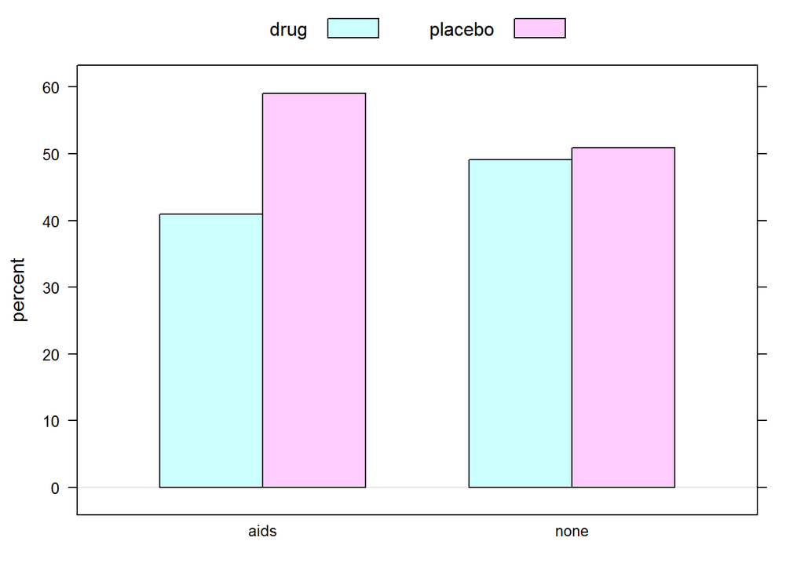

```r
results <- xtabs(~infected+treatment,data=abac)
barchartGC(results,type = "percent")
```

The placebo seems to been taken more than the drugs. As you can see we have 59% plocebo with aids and 50% without aids. The drugs was taken 40% with aids and 49% without aids.

### Numerical Descriptive Results

```r
colPerc(results)
```

```
##         treatment
## infected   drug placebo
##    aids    4.04    5.54
##    none   95.96   94.46
##    Total 100.00  100.00
```

```r
rowPerc(results)
```

```
##         treatment
## infected   drug placebo  Total
##     aids  40.93   59.07 100.00
##     none  49.10   50.90 100.00
```

There was treament for infected patients with aids that took the drugs with a 4.04% and placebo 5.54%. Without aids had drugs at 95.96% and placebo at 94.46%.

## Inferential Results

```
## Pearson's Chi-squared test with Yates' continuity correction
##
## Observed Counts:
##         treatment
## infected drug placebo
##     aids   97     140
##     none 2303    2387
##
## Counts Expected by Null:
##         treatment
## infected    drug placebo
##     aids  115.45  121.55
##     none 2284.55 2405.45
##
## Contributions to the chi-square statistic:
##         treatment
## infected drug placebo
##     aids 2.95    2.80
##     none 0.15    0.14
##
##
## Chi-Square Statistic = 5.7138
## Degrees of Freedom of the table = 1
## P-Value = 0.0168
```

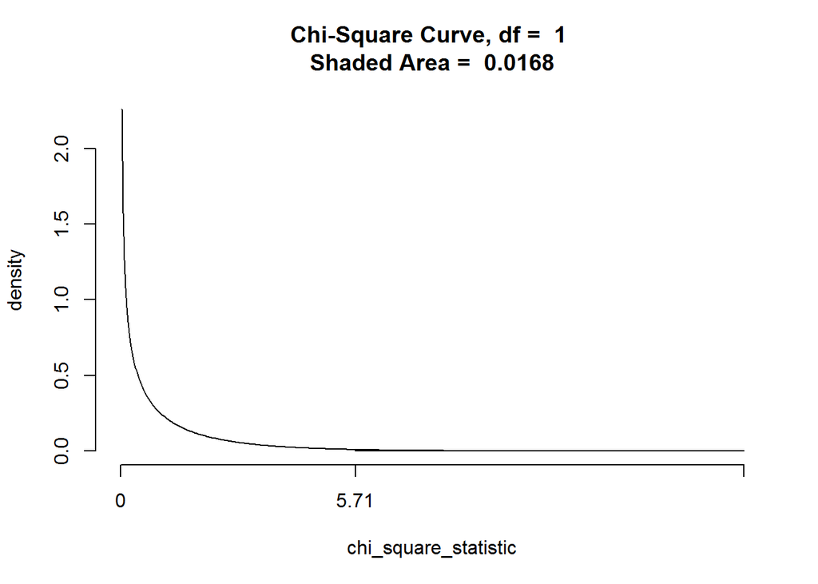

```r
chisqtestGC(results, graph = TRUE)
```

Using variables to get statistics on Counts by null and contributions to the chi-square statistic. The null had infected with aids using drugs at 115.45% and placebo at 121.55%. Without aids at 2284.55% and without drugs at 2405.45%. The contributions to the chi-square statistic infected with aids and drugs at 2.95% and without drugs and without aids at 2.80%. Last without being infected with aids but with drugs at 0.15% and with being infected with aids and with placebo at 0.14%.

The chi-square curve, df=1 and the shaed area is 0.0168. The density is passed 2.0 % and the chi_square_statistic is 5.71%.

```r
fisher.test(results)
```

```
##
##  Fisher's Exact Test for Count Data
##
## data:  results
## p-value = 0.01634
## alternative hypothesis: true odds ratio is not equal to 1
## 95 percent confidence interval:
##  0.5449798 0.9433871
## sample estimates:
## odds ratio
##  0.7181794
```

The alternative hypothesis has true odds ratio that is not equal to one. P-value has results of 0.01634%. Sample estimate odd ratio at 0.7181794%.

# Discussion and Conclusion

I found that patients with or without aids seemed to be taken more of the placebo than the drugs slightly. Which have me asking more questions about did the patients taken the placebo feel better or worse after taken the treatment. Same with the patients taken the drugs, did they feel better or worse.

# Female

# Results

## Descriptive Results

### Graphical Descriptive Results

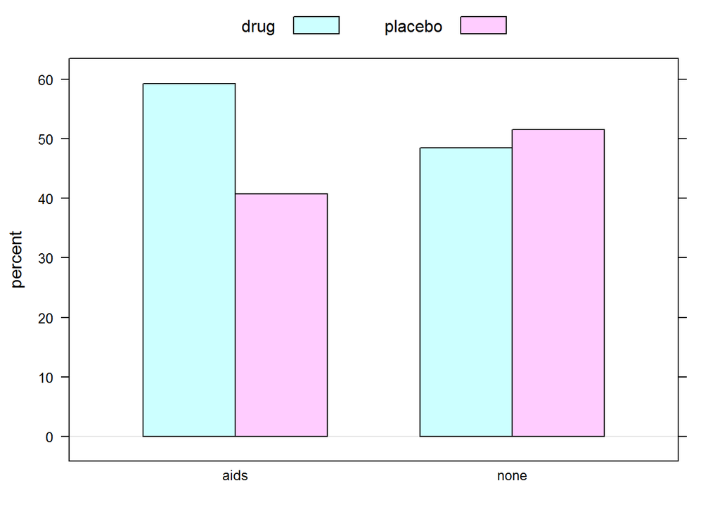

```r
results <- xtabs(~infected+treatment,data=Female)
barchartGC(results,type = "percent")
```

### Numerical Descriptive Results

```r
colPerc(results)
```

```
##         treatment
## infected   drug placebo
##    aids    3.96    2.59
##    none   96.04   97.41
##    Total 100.00  100.00
```

```r
rowPerc(results)
```

```
##         treatment
## infected   drug placebo  Total
##     aids  59.30   40.70 100.00
##     none  48.47   51.53 100.00
```

The treatment with infected aids patients and drugs is at 59.30% and infected aids patients with placebo is at 40.70%. The treatment not infected with aids but have taken the drugs are at 48.47% and without aids and with placebo are at 51.53%.

## Inferential Results

```
## Pearson's Chi-squared test with Yates' continuity correction
##
## Observed Counts:
##         treatment
## infected drug placebo
##     aids   51      35
##     none 1237    1315
##
## Counts Expected by Null:
##         treatment
## infected    drug placebo
##     aids   41.99   44.01
##     none 1246.01 1305.99
##
## Contributions to the chi-square statistic:
##         treatment
## infected drug placebo
##     aids 1.93    1.84
##     none 0.07    0.06
##
##
## Chi-Square Statistic = 3.4843
## Degrees of Freedom of the table = 1
## P-Value = 0.062
```

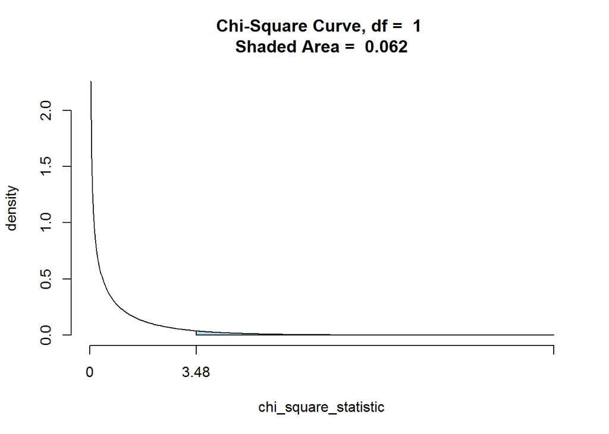

```r
chisqtestGC(results, graph = TRUE)
```

The Curve results is chi-square curve, df=1 and shaded area is 0.062. The density is over 2.0% and ch_square_statistic is at 3.48%.

```r
fisher.test(results)
```

```
##
##  Fisher's Exact Test for Count Data
##
## data:  results
## p-value = 0.04911
## alternative hypothesis: true odds ratio is not equal to 1
## 95 percent confidence interval:
##  0.980258 2.472003
## sample estimates:
## odds ratio
##   1.548757
```

Fisher’s Exact test for count data is p-value= 0.04911 and alternative hypothesis: true odds ratio is not equal to 1% but 95% confidence interval: 0.980258% and 2.472003. Sample estimates: odds ratio is 1.548757%.

# Discussion and Conclusion

For women again the results is not that big of a difference. Which makes me want to ask questions on how the treaments went for the women with aids and without. Also the women without aids and using the placebo. Did they feel better or worse?

# Male

# Results

## Descriptive Results

### Graphical Descriptive Results

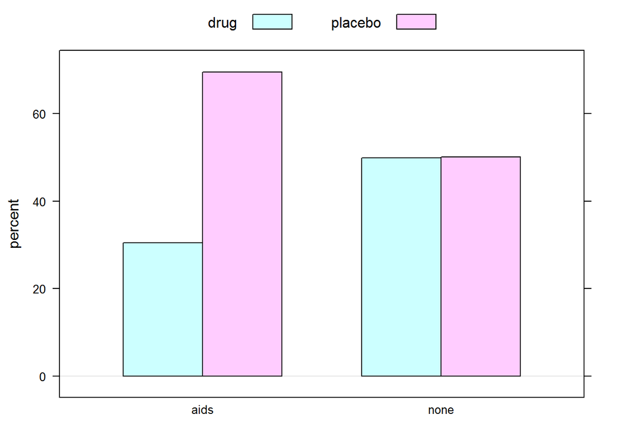

```r
results <- xtabs(~infected+treatment,data=Male)
barchartGC(results,type = "percent")
```

### Numerical Descriptive Results

```r
colPerc(results)
```

```
##         treatment
## infected   drug placebo
##    aids    4.14    8.92
##    none   95.86   91.08
##    Total 100.00  100.00
```

```r
rowPerc(results)
```

```
##         treatment
## infected   drug placebo  Total
##     aids  30.46   69.54 100.00
##     none  49.86   50.14 100.00
```

For the treament of men with aids and with drugs is 30.46% and with aids and with placebo is 69.54%. The treatment without drugs and aids is 49.86% and the treatment without drugs and with placebo is 50.14%.

## Inferential Results

```
## Pearson's Chi-squared test with Yates' continuity correction
##
## Observed Counts:
##         treatment
## infected drug placebo
##     aids   46     105
##     none 1066    1072
##
## Counts Expected by Null:
##         treatment
## infected    drug placebo
##     aids   73.36   77.64
##     none 1038.64 1099.36
##
## Contributions to the chi-square statistic:
##         treatment
## infected  drug placebo
##     aids 10.20    9.64
##     none  0.72    0.68
##
##
## Chi-Square Statistic = 20.4718
## Degrees of Freedom of the table = 1
## P-Value = 0
```

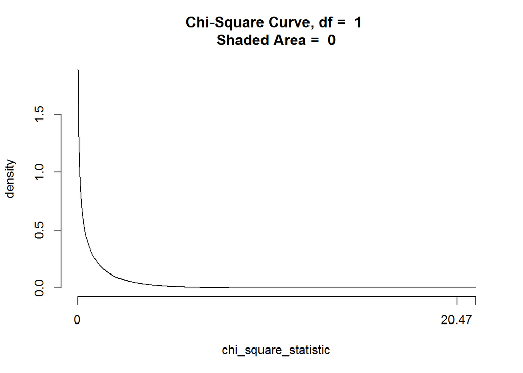

```r
chisqtestGC(results, graph = TRUE)
```

This graph for the Chi-Square Curve, df=1 and shaded area = 0. The density is over 1.5% and the chi_square_statistic is at 20.47%.

```r
fisher.test(results)
```

```
##
##  Fisher's Exact Test for Count Data
##
## data:  results
## p-value = 4.352e-06
## alternative hypothesis: true odds ratio is not equal to 1
## 95 percent confidence interval:
##  0.3013934 0.6360948
## sample estimates:
## odds ratio
##  0.4407101
```

# Discussion and Conclusion

The results for men with aids and with placebo is higher than men without aids and with placebo.However, the results without drugs and with placebo are the same.

# Druggies

# Results

## Descriptive Results

### Graphical Descriptive Results

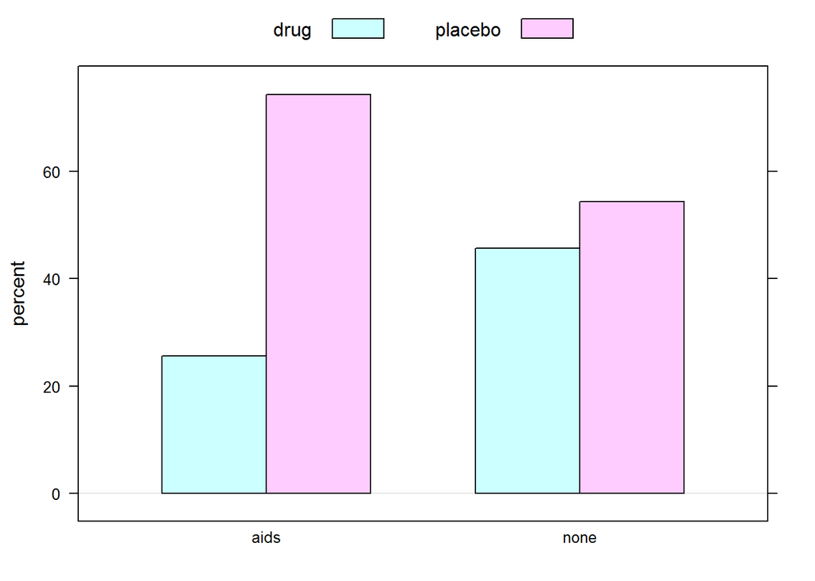

```r
results <- xtabs(~infected+treatment,data=Druggies)
barchartGC(results,type = "percent")
```

The barchart shows that druggies with aids and taking the drugs is at 25%, and druggies with aids and taking placebo is at 75%. Also showing that druggies without aids and drugs is at 45%, and druggies without aids and placebo is at 55%.

### Numerical Descriptive Results

```r
colPerc(results)
```

```
##         treatment
## infected   drug placebo
##    aids    3.17     7.4
##    none   96.83    92.6
##    Total 100.00   100.0
```

```r
rowPerc(results)
```

```
##         treatment
## infected   drug placebo  Total
##     aids  25.64   74.36 100.00
##     none  45.66   54.34 100.00
```

The treament infected with aids and taking drugs is 25.64%, with aids and taking the placebo is 74.36%. While the treament without aids and taking drugs is 45.66%, without aids and placebo is 54.34%.

## Inferential Results

```
## Pearson's Chi-squared test with Yates' continuity correction
##
## Observed Counts:
##         treatment
## infected drug placebo
##     aids   10      29
##     none  305     363
##
## Counts Expected by Null:
##         treatment
## infected   drug placebo
##     aids  17.38   21.62
##     none 297.62  370.38
##
## Contributions to the chi-square statistic:
##         treatment
## infected drug placebo
##     aids 3.13    2.52
##     none 0.18    0.15
##
##
## Chi-Square Statistic = 5.1942
## Degrees of Freedom of the table = 1
## P-Value = 0.0227
```

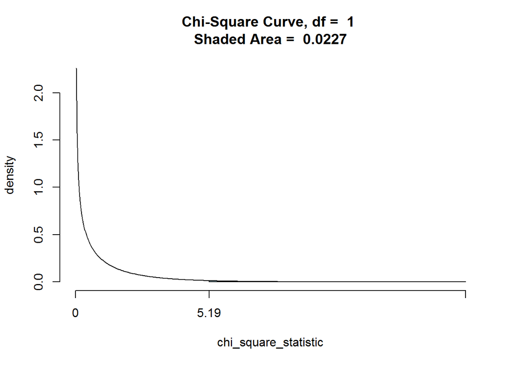

```r
chisqtestGC(results, graph = TRUE)
```

Using variables to get statistics on Counts by null and contributions to the chi-square statistic. The null had infected with aids using drugs at 17.38% and placebo at 21.62%. Without aids at 297.62% and without drugs at 370.38%. The contributions to the chi-square statistic infected with aids and drugs at 3.13% and without drugs and without aids at 2.52%. Last without being infected with aids but with drugs at 0.18% and with being infected with aids and with placebo at 0.15%.

The chi-square curve, df=1 and shaded area = 0.0227. The density is over 2.0% and the chi_square_statistic is 5.19%.

```r
fisher.test(results)
```

```
##
##  Fisher's Exact Test for Count Data
##
## data:  results
## p-value = 0.01929
## alternative hypothesis: true odds ratio is not equal to 1
## 95 percent confidence interval:
##  0.1757111 0.8844152
## sample estimates:
## odds ratio
##  0.4108953
```

# Discussion and Conclusion

I found that the druggies with aids and with drugs were far lower and without aids with drugs are slightly lower.Higher with druggies with aids and placebo and slightly higher with druggies without aids with placebo.

# LGBT

# Results

## Descriptive Results

### Graphical Descriptive Results

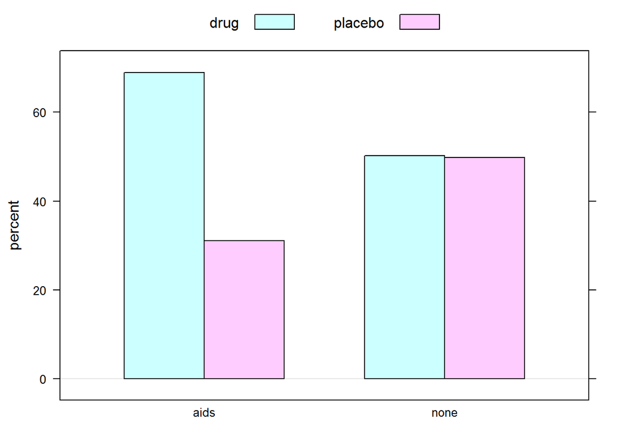

```r
results <- xtabs(~infected+treatment,data=LGBT)
barchartGC(results,type = "percent")
```

### Numerical Descriptive Results

```r
colPerc(results)
```

```
##         treatment
## infected   drug placebo
##    aids    6.51    3.06
##    none   93.49   96.94
##    Total 100.00  100.00
```

```r
rowPerc(results)
```

```
##         treatment
## infected   drug placebo  Total
##     aids  68.97   31.03 100.00
##     none  50.17   49.83 100.00
```

The treatment with aids and with drugs is 68.97% and with aids and placebo is 31.03%. The treatment without aids and with drugs is 50.17%, and without aids and with placebo is 49.83%.

## Inferential Results

```
## Pearson's Chi-squared test with Yates' continuity correction
##
## Observed Counts:
##         treatment
## infected drug placebo
##     aids   20       9
##     none  287     285
##
## Counts Expected by Null:
##         treatment
## infected   drug placebo
##     aids  14.81   14.19
##     none 292.19  279.81
##
## Contributions to the chi-square statistic:
##         treatment
## infected drug placebo
##     aids 1.82    1.90
##     none 0.09    0.10
##
##
## Chi-Square Statistic = 3.1843
## Degrees of Freedom of the table = 1
## P-Value = 0.0743
```

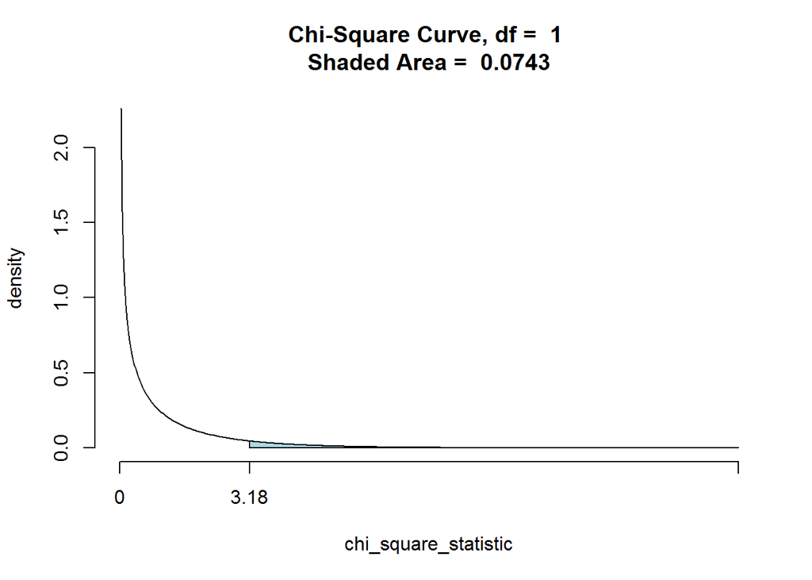

```r
chisqtestGC(results, graph = TRUE)
```

Using variables to get statistics on Counts by null and contributions to the chi-square statistic. The null had infected with aids using drugs at 14.81% and placebo at 14.19%. Without aids at 292.19% and without drugs at 279.81%. The contributions to the chi-square statistic infected with aids and drugs at 1.82% and without drugs and without aids at 1.90%. Last without being infected with aids but with drugs at 0.09% and with being infected with aids and with placebo at 0.10%.

The chi-square curve, df=1 and shaded area = 0.0743. The density is over 2.0% and chi_square_statistic is 3.18%.

```r
fisher.test(results)
```

```
##
##  Fisher's Exact Test for Count Data
##
## data:  results
## p-value = 0.05698
## alternative hypothesis: true odds ratio is not equal to 1
## 95 percent confidence interval:
##  0.9400645 5.5951059
## sample estimates:
## odds ratio
##   2.203969
```

# Discussion and Conclusion